# 01. 서론

- 예측은 수천년전부터 지금까지 사람들의 마음을 사로잡고 있습니다. 어떤 때는 예측이 신적인 영감의 흔적으로 간주되기도 하고, 어떤 때는 범죄 행동으로 여겨지기도 했습니다. 유대인 선지자 이사야는 기원전 700년 경에 이렇게 적었습니다.

```
뒤에 올 일을 알게 하라 그리하면 너희가 신들인 줄 우리가 알리라 또 복을 내리든지 재난을 내리든지 하라 우리가 함께 보고 놀라리라
(이사야 41:23; 개역개정판)
```

- 백년 뒤 고대 바빌로니아의 예측가는 썩은 양의 간에서 구더기의 분포를 보고 미래를 예언하였습니다. 기원전 300년까지 예측을 원하는 사람들은 에틸렌 증기에 도취된 여인의 예측을 통한 신탁을 구하기 위해 그리스의 델피로 여행을 떠났습니다. 예측가들은 로마 콘스탄티누스 황제의 통치 아래에서 힘든 시간을 보냈습니다. 서기 357년에 점쟁이, 수학자, 예측가에게 의견을 구하는 것을 일체 금지하는 칙령을 내렸고, 미래를 예언하려는 호기심은 영원히 잠잠해지는 것 같았습니다. 1736년 영국에서 예측 사기로 돈을 뜯어내는 것이 범죄가 되었을 때 예측에 대한 비슷한 금지령이 있었습니다. 3개월의 수감 생활과 강제 노동이 형벌이었습니다!
- 나쁜 예측은 위험할 수 있었지만, 좋은 예측은 거의 마법처럼 보였기 때문에 예측가의 운명이 바뀌는 일이 생깁니다. 컴퓨터에 관한 유명한 예측을 살펴봅시다.

```
- 내 생각에 컴퓨터에 대한 전세계의 수요는 다섯 대 정도일 것이다. (Chairman of IBM, 1943)
- 미래에는 컴퓨터의 무게가 아마도 1.5톤을 넘지 않을 것이다. (Popular Mechanics, 1949)
- 개개인이 컴퓨터를 자기 집에 두고 싶어할 이유는 없다. (President, DEC, 1977)
```

- 위의 언급 중에서 마지막 것은 IBM이 최초의 개인용 컴퓨터를 생산하기 단지 3년전에 꺼낸 이야기입니다. 이제는 놀라울 것도 없지만, 여러분은 더이상 DEC 컴퓨터를 시장에서 찾아볼 수가 없습니다. 분명히 예측은 힘든 활동이고, 잘 했을 때는 실패했을 때보다 장점이 많은 사업입니다.
- 우리는 이 책에서 예측값을 만들어내는 가장 신뢰할만한 몇몇 기법을 살펴볼 것입니다. 재현 가능하면서 검증 가능한 그리고 업계에서 유용하다고 알려진 기법을 위주로 공부할 것입니다.

## 01.01 예측 될 수 있는 것이란?

- 많은 경우에 예측이 필요합니다. 향후 5년 안에 발전소를 지을지 말지 결정하려면 미래 수요 예측이 필요합니다. 콜센터에서 직원 일정을 조율하려면 통화량 예측이 필요합니다. 재고를 관리하려면 공급량 예측이 필요합니다. (자본 투자의 경우에는) 몇 년 앞 예측이 필요할 수 있고, (통신 경로의 경우에는) 단지 몇 분 앞 예측이 필요할 수 있습니다. 관련된 상황이나 시간적 범위가 무엇이든, 효율적이며 효과적인 계획을 세우는데 예측은 큰 도움이 됩니다.
- 상대적으로 예측하기 쉬운 것도 있습니다. 내일 아침에 해가 뜰 시간은 정확하게 예측할 수 있습니다. 반대로, 내일 로또 당첨 번호는 정확하게 예측할 수 없습니다. 어떤 사건이나 수량의 예측가능성은 다음과 같은 몇 가지 요인에 의존합니다.

```
1. 영향을 주는 요인을 얼마나 잘 이해할 수 있는지
2. 사용할 수 있는 데이터가 얼마나 많은지
3. 예측이 우리가 예측하려는 것에 영향을 줄 수 있는지 여부
```

- 예를 들면, 전기 수요 예측의 경우는 보통 세 가지 조건이 모두 만족되기 때문에 상당히 정확할 수 있습니다. 우리는 전기 수요가 기온에 영향을 크게 받고, 휴일이나 경제적인 요인에 의해 영향을 적게 받는다는 사실을 잘 알고 있습니다. 전기 수요와 날씨 상황에 대해 시간에 따른 충분한 데이터가 있고, 전기 수요와 핵심 변수를 관련지어 잘 설명할 수 있는 모델을 세울 수 있는 기술도 있어서, 놀라울 정도로 정확하게 예측할 수 있습니다.
- 반대로, 환율 예측의 경우에는 사용할 수 있는 데이터가 충분히 많다는 한 가지 조건만 만족됩니다. 하지만, 환율에 영향을 주는 요인을 잘 모르고, 환율 예측은 환율 자체에 직접적으로 영향을 주기도 합니다. 만약에, 환율이 증가할 것이라는 예측이 아주 잘 공개된다면, 사람들은 즉시 가격을 조정할 것입니다. 즉, 사람들이 돈을 기꺼이 지불하는 상황이 벌어져, 예측 자체 때문에 예측이 맞는 상황이 되고 맙니다. 이러한 의미에서, 환율은 점점 스스로를 예측하게 되는 셈입니다. 이것은 “효율적인 시장 가설(efficient market hypothesis)”의 한 예입니다. 따라서, 환율이 내일 올라갈지 떨어질지 예측하는 것은 던진 동전이 앞 면으로 떨어질지 뒷 면으로 떨어질지 예측하는 것과 거의 비슷합니다. 두 경우 모두, 무엇을 예측하던지 50% 가까이는 맞을 것입니다. 이러한 경우에, 예측하는 사람은 스스로의 한계를 자각할 필요가 있고, 더 잘 맞추는 것이 가능하다고 주장하지 말아야 할 필요가 있습니다.
- 종종 예측에 있어서 핵심적인 과정은 정확한 예측이 가능한 때가 언제인지와, 그리고 예측이 큰 의미가 없을 때(예측을 하는 것이 동전을 던진 결과로 의사결정을 하는 것보다 나을 것이 없을 때)가 언제인지를 아는 것입니다. 좋은 예측은 과거 데이터에서 존재하는 진짜 패턴과 관계를 잡아내지만, 다시 반복되지 않을 과거 사건을 정확히 모사하지는 않습니다. 이 책에서는 과거 데이터에서 무시해야하는 무작위적인 요동과 모델링하고 외삽(extrapolate)해야 할 진짜 패턴의 차이를 어떻게 구분할 지 공부할 것입니다.
- 많은 사람이 환경이 변하는 경우에 예측이 불가능할 것이라는 잘못된 방식으로 가정합니다. 모든 환경은 변하고, 좋은 예측 모델은 변하는 방식을 잡아냅니다. 예측할 때 환경이 변하지 않는다는 가정은 잘 사용하지 않습니다. 보통은 환경이 변하는 방식이 미래에도 계속 될 것이라고 가정합니다. 즉, 아주 불안정한 환경은 계속하여 아주 불안정할 것이고, 판매량이 변하는 사업은 계속 판매량이 변할 것이고, 호황과 불황 패턴을 보이는 경제에는 계속하여 호황과 불황이 나타날 것이라는 내용입니다. 예측 모델은 존재하는 상황만이 아니라, 변하는 방식을 잡아내는 것을 목적으로 합니다. 아브라함 링컨(Abraham Lincoln)이 말한 것처럼, “먼저 우리가 어디에 있고 어디로 향하고 있는지 알 수 있다면, 우리는 무엇을 어떻게 할 것인지 더 잘 결정할 수 있을 것입니다.”
- 예측하는 일은 시간 범위에 따라, 실제 결과를 결정하는 요인에 따라, 데이터의 패턴의 종류에 따라, 그리고 그 밖의 많은 양상에 따라 많이 달라집니다. 예측 기법은 (단순(naïve) 기법이라고 불리는) 가장 최근의 관측값을 예측값로 사용하는 것처럼 단순할 수도 있고, 신경망(neural network)이나 계량경제학적(econometric) 시스템을 다루는 연립방정식처럼 아주 복잡할 수도 있습니다. 어떤 때는, 사용할 수 있는 데이터가 아예 없을 수도 있습니다. 예를 들면, 신제품의 첫 해 판매량을 예측하고 싶다고 하는 상황에는, 당연하게도 예측 작업에 사용할 데이터가 없습니다. 이와 같은 상황에서는 4 장에서 다룰 판단 예측을 사용합니다. 어떤 종류의 데이터를 사용할 수 있는지와 수량의 예측가능성에 따라 사용할 기법이 달라집니다.

## 01.02 예측, 계획 그리고 목표

예측은 경영분야에 있어서 생산 계획, 수송, 인사에 관한 결정을 알리거나 장기 전략 계획을 세우는데 도움을 줄 수 있는 흔한 통계적 업무입니다. 하지만, 경영 예측은 부실하게 이루어지는 경우가 잦고, 종종 계획이나 목표 수립 작업과 혼동되기도 합니다. 아래 세 가지는 서로 다른 요소입니다.

#### 예측

이란 주어진 이용가능한 모든 정보(과거 데이터 및 예측에 영향을 끼칠 수 있는 미래 사건에 대한 지식을 포함)를 바탕으로 가능한 한 정확하게 미래를 예측하는 것입니다.

#### 목표

는 예측 및 계획과 연관되어 있는 것이 좋지만, 이것이 항상 일어나는 것은 아닙니다. 목표를 어떻게 달성할지에 대한 계획과 목표가 실현 가능한지에 대한 예측 없이 목표를 세우는 경우가 너무나도 자주 있습니다.

#### 계획

은 예측과 목표에 대한 대응입니다. 계획은 여러분의 예측과 목표를 일치시키는데 필요한 적절한 행동을 결정하는 일을 포함합니다. 회사의 많은 영역에서 중요한 역할을 할 수 있기 때문에, 예측은 경영에서 의사결정 행동에 있어서 중요한 요소가 되어야합니다. 현대 기업들은 특정한 용도에 따라 단기, 중기, 장기 예측을 필요로 하고 있습니다.

#### 단기 예측

은 인사, 생산, 수송 계획 등에 필요합니다. 계획 과정의 한 부분으로 수요 예측도 필요합니다.

#### 중기 예측

은 원자재 구입, 신규 채용, 장비나 기계 구입 등 미래 자원 공급을 결정하는데 필요합니다.

#### 장기 예측

은 전략적으로 계획을 세우는데 사용합니다. 시장 기회, 환경 요인, 내부 자원을 반드시 고려하여 결정합니다.

기업은 몇 가지 접근 방식을 가지고 분명하지 않은 사건을 예측하는 시스템 구축을 필요로 합니다. 이러한 예측 시스템에는 예측할 문제를 찾는 것, 적용할 예측 기법의 범위를 선택하는 것, 각 문제에 적합한 기법을 선택하는 것, 시간에 따라 예측 기법을 평가하고 다듬는 것에 관한 전문 역량을 개발하는 일이 필요합니다. 성공적으로 사용될 예측 기법이라면, 공식적인 예측 기법으로 정착하기 위해서 기업의 적극적인 지원도 중요합니다.

## 01.03 어떤 것을 예측할 지 결정하기

예측 프로젝트의 초기 단계에서 어떤 것을 예측해야하는지 결정하는 일이 필요합니다. 예를 들면, 생산 환경에서 물품에 대한 예측이 필요하다면, 다음과 같은 것에 대해 예측이 필요한지 아닌지 질문하는 일이 필요합니다.

```
1. 모든 생산 라인에 대한 것인가? 생산 그룹에 대한 것인가?
2. 모든 판매점에 대한 것인가? 지역별 판매점 그룹에 대한 것인가? 전체 판매량에 대한 것인가?
3. 주별 데이터인가? 월별 데이터인가? 연간 데이터인가?
```

예측 범위를 고려하는 것도 필요합니다. 한 달, 6개월, 10년 앞 예측이 필요한가? 어떤 예측 범위가 가장 중요한 지에 따라 다른 종류의 모델이 필요할 것입니다.

예측 작업을 얼마나 자주해야할까요? 예측값을 자주 내야하는 경우에는 세심한 수작업이 필요한 기법보다는 자동화된 시스템을 이용하는 것이 더 낫습니다.

예측값을 만들기 위한 대규모 작업에 나서기 전에, 시간을 내서 예측값을 사용할 사람과 대화하며, 여러분이 사용자의 필요를 이해하는지와 사용자가 예측값을 어떻게 사용할지 확실하게 파악하는 것이 좋습니다.

어떤 예측이 필요할지 결정하면, 예측에 사용할 데이터를 찾거나 모으는 일이 필요합니다. 예측에 필요한 데이터는 이미 존재할 수도 있습니다. 요즘은 많은 데이터가 기록되어있어서 예측하는 사람들이 종종 어디에 어떻게 데이터가 저장되어있는지 알아내는 작업도 합니다. 데이터는 회사의 판매 기록, 상품의 과거 수요, 지역의 실업률 등일 수 있습니다. 예측하는 사람이 시간을 가장 많이 쏟는 부분은 적합한 예측 기법을 개발하기 전에 가능한 데이터를 찾고 모아서 분석하는 것입니다.

## 01.04 예측 데이터와 기법

주로 어떤 데이터를 사용할 수 있는지에 따라 적절한 예측 기법이 달라집니다.

이용할 수 있는 데이터가 없거나, 이용할 수는 있지만 예측에 상관 없는 데이터라면, 정성적인 예측 기법을 사용해야합니다. 이러한 기법은 그냥 단순한 짐작이 아닙니다. 과거 데이터를 이용하지 않고 좋은 예측값을 내도록 잘 개발된 구조화된 접근법입니다. 4장에서 이러한 기법을 다룹니다.

**정량적인 예측**은 두 가지 조건을 만족할 때 사용할 수 있습니다.

```
과거 수치 정보를 사용할 수 있을 때
과거 패턴의 몇 가지 양상이 미래에도 계속될 것이라고 가정하는 것이 합리적일 때
```

종종 특정한 분야에서 특정한 목적을 위하여 개발된 여러 정량적 예측 기법이 있습니다. 특정 기법을 선택할 때는 각 기법의 특성, 정확도, 비용 등을 반드시 고려해야합니다.

대부분의 정량적인 예측 문제는 (시간에 따라 일정한 간격으로 모든) 시계열이나 (특정 시점에서 모은) 횡단면(cross-sectional) 데이터를 사용합니다. 미래 데이터를 예측하는 일이 이 책의 주제이니, 시계열 영역에 집중하겠습니다.

### 시계열 예측

다음과 같은 문제는 시계열 데이터로 다룰 수 있습니다.

```
- IBM 일별 주가
- 월 별 강우량
- Amazon의 분기별 판매 결과
- Google의 연간 수익
```

위와 같이 시간에 따라 순차적으로 관측된 것을 시계열로 다룰 수 있습니다. 이 책에서는 (예를 들면, 시간별, 일별, 주별, 월별, 분기별, 연간) 일정한 시간 간격에 따라 관측된 시계열만 다룰 것입니다. 시간 간격이 불규칙적인 시계열도 있을 수 있습니다만, 이 책에서는 다루지 않습니다.

시계열 데이터를 예측할 때, 목표는 관측값의 수열이 미래에 계속될 것인지 예측하는 것입니다. 그림 1.1은 1992년부터 2010년 2분기까지 호주 맥주의 분기별 생산량입니다.

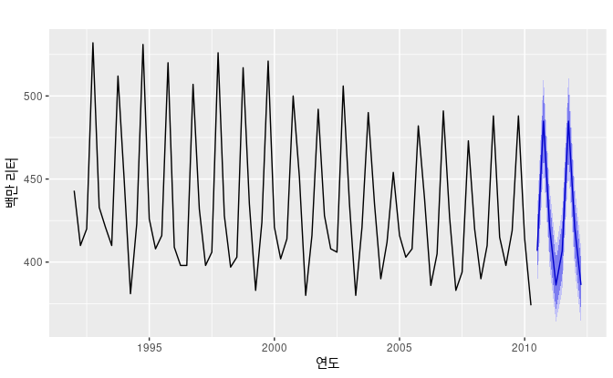

파란색 선은 다음 2년에 대한 예측값입니다. 예측값들이 과거 데이터에서 나타나는 계절성 패턴을 얼마나 잘 잡아내는지 그리고 다음 2년에 대해 얼마나 잘 모사하는지 주목하시길 바랍니다. 어둡게 그늘로 표시한 영역은 80% 예측 구간(prediction interval)을 의미합니다. 즉, 각 미래값이 80% 확률로 어두운 그늘로 표시한 영역에 들어갈 것으로 예측하고 있습니다. 밝은 그늘로 표시한 영역은 95% 예측 구간을 의미합니다. 이러한 예측 구간은 예측의 불확실성을 나타낼 때 쓸모가 있습니다. 이 경우에는 예측값이 정확할 것으로 예상되고, 따라서 예측 구간이 아주 좁습니다.

가장 단순한 시계열 예측 기법은 예측할 변수 정보만 이용하고, 변수의 행동에 영향을 미치는 다른 요인들을 고려하지 않습니다. 이러한 기법은 추세와 계절성 패턴을 외삽(extrapolate)하지만, 마케팅 계획이나 경쟁사의 활동, 경제 상황 변화 등의 다른 모든 정보를 무시합니다.

시계열 예측용 모델에는 분해 모델, 지수 평활, ARIMA 모델 등이 있습니다. 6, 7 , 8 장에서 각각 이러한 모델을 다룹니다.

### 예측 변수와 시계열 예측

예측 변수(predictor variable)는 시계열을 예측할 때 종종 유용합니다. 예를 들어, 여름 기간 동안 더운 지역의 시간당 전기 수요(ED, electricity demand)를 예측하려는 상황을 생각해봅시다. 예측 변수를 고려하는 모델은 이러한 형태일 것입니다.

$\begin{align*} \text{ED} = & f(\text{현재 기온, 경제 상황, 인구,시간, 요일, 오차})\\ \end{align*}$

예측 변수로 (완벽하게) 설명할 수 없는 전기 수요량은 항상 변화할 것이기에 이 관계는 정확하지 않습니다. 위의 모델에서 우변에 있는 “오차(error)”항은 무작위 변동과 더불어 모델에 포함하지 않은 관련 변수의 영향까지 고려하는 역할을 합니다. 어떤 것이 전기 수요의 변동을 일으키는지 설명할 때 도움이 되기 때문에 이 모델을 **설명 모형(explanatory model)이라고 부릅니다.**

전기 수요 데이터가 시계열이라서, 예측할 때 시계열 모델을 사용할 수도 있습니다. 이 경우에, 적합한 시계열 예측식의 형태는 다음과 같습니다.

$\text{ED}_{t+1} = f(\text{ED}_{t}, \text{ED}_{t-1}, \text{ED}_{t-2}, \text{ED}_{t-3},\dots, \text{오차}),$

여기에서 $t$는 현재 시간, $t+1$은 한 시간 후, $t−1$은 한 시간 전, $t−2$는 2시간 전, 나머지도 이와 같습니다. 여기에서는 변수의 과거 값으로 미래 예측을 합니다만, 시스템에 영향을 줄 수 있는 외부 변수는 사용하지 않습니다. 또 다시, 우변의 “오차(error)” 항으로 무작위 변동과 모델에 넣지 않은 관련 변수의 효과를 감안합니다.

위의 두 모델의 특징을 결합한 세 번째 종류의 모델도 있습니다. 예를 들어, 다음과 같이 주어질 것입니다.

$\text{ED}_{t+1} = f(\text{ED}_{t}, \text{현재 기온, 시간, 요일, 오차}).$

이러한 종류의 “혼합된 모델(mixed models)”은 분야에 따라 다양한 이름으로 불립니다. 동적 회귀(dynamic regression) 모델, 패널(panel) 데이터 모델, 종단적(longitudinal) 모델, 수송 함수(transfer function) 모델, ($f$가 선형이라고 가정하는) 선형 시스템(linear system) 모델이라고 알려져 있습니다. 9 장에서 이러한 모델을 다룹니다.

예측하려는 변수의 과거 값만 다루지 않고 다른 변수에 관한 정보도 포함하기 때문에 설명 모형은 유용합니다. 하지만, 예측하는 사람이 설명 모델이나 혼합된 모델 대신에 시계열 모델을 선택할 수도 있는 몇 가지 이유가 있습니다. 먼저, 시스템을 잘 이해하지 못하거나, 이해하더라도 변수의 행동에 영향을 주는 관계를 측정하기가 아주 어려운 경우입니다. 다음, 관심 있는 변수를 예측할 수 있으려면 다양한 예측 변수의 미래값을 알 필요가 있거나 예측할 필요가 있는 경우입니다. 그리고, 주된 관심이 왜 일어나는지가 아니라 무엇이 일어나는지만 예측하는데 있는 경우입니다. 마지막으로, 시계열 모델이 설명 모델이나 혼합 모델보다 더 정확한 예측값을 내는 경우입니다.

사용할 수 있는 자원과 데이터, 비교 모델의 정확도, 예측 모델이 사용될 방식에 따라 예측에 사용할 모델이 달라집니다.

## 01.05 몇 가지 사례 연구

다음의 네 가지 사례는 이 책의 저자 2명이 진행했던 컨설팅 업무에서 가져왔습니다. 이러한 사례는 다른 종류의 갖가지 예측 상황과 자주 등장하는 관련 문제를 보여줍니다.

#### 사례 1

냅킨이나 종이 접시 같은 1회용 식탁용 식기류를 생산하는 큰 회사가 고객이었습니다. 매달 수백개의 품목에 대해 예측이 필요했습니다. 시계열 데이터를 보니 다양한 패턴, 몇 가지는 추세(trend)가 있고, 몇 가지는 계절성(seasonality)이 있지만 몇 가지는 그렇지 않기도 했습니다. 당시에, 고객은 자체적으로 개발한 소프트웨어를 사용하고 있었지만, 그 소프트웨어는 합리적인 것 같지 않은 예측값을 자주 냈습니다. 사용하고 있던 기법은 다음과 같습니다.

```
1. 이전 12개월 데이터를 평균
2. 이전 6개월 데이터를 평균
3. 이전 12개월 데이터에 기반한 선형회귀를 통하여 예측
4. 이전 6개월 데이터에 기반한 선형회귀를 통하여 예측
5. 작년과 금년의 관측값들을 잇는 직선들의 평균 기울기를 가지면서 가장 최근의 관측값을 통과하는 직선으로 얻은 예측
6. 최근 6개월 동안만의 관측값들을 잇는 직선들의 평균 기울기를 가지면서 가장 최근의 관측값을 통과하는 직선으로 얻은 예측
```

고객사에서는 우리에게 무엇이 잘못되었는지 알려달라는 것과 소프트웨어가 더 정확한 예측값을 내도록 수정해달라는 것을 요청했습니다. 고객사의 소프트웨어는 COBOL로 작성한 것이라 복잡한 수치 계산을 하기에는 어려웠습니다.

#### 사례 2

이 사례에서는 호주의 의약품 혜택 제도(PBS, Pharmaceutical Benefit Scheme)에 들어가는 연간 예산을 예측하길 원했던 호주 연방 정부가 고객이었습니다. PBS는 호주의 많은 의약품에 대한 지원금을 제공하고 사람들이 1년 동안 어떤 것을 구매하느냐에 따라 PBS 지출이 달라집니다. 2009년 총 지출은 약 70억 호주 달러였는데, 저자들이 더 정확한 예측 방법 개발을 도와달라는 요청을 받기 전에는 2년마다 거의 10억 호주 달러가 적게 추정되어 왔습니다.

전체 지출을 예측하기 위해, 월별 데이터를 사용하여 수백개의 의약품 그룹의 판매량을 예측하는 작업이 필요했습니다. 거의 모든 그룹이 추세와 계절성 패턴을 갖고 있었습니다. 많은 의약품 그룹에서 어떤 의약품에 보조금이 지원되느냐에 따라 갑작스런 증가나 감소가 나타났습니다. 많은 의약품 그룹에서 더 저렴한 경쟁 의약품을 구할 수 있게 되는 것 때문에 지출에 갑작스런 변화가 일어나기도 했습니다.

따라서 추세(trend)와 계절성(seasonality)이 있을 때 이러한 요소를 고려하면서, 동시에 기본적인 패턴의 갑작스런 변화에도 강한 예측 기법을 찾아야 했습니다. 많은 수의 시계열에 자동으로 적용할 수도 있어야 했습니다.

#### 사례 3

규모가 큰 자동차 회사에서 차량 재판매량 예측을 도와달라는 요청을 받았습니다. 회사에서 새로운 차량을 구입하고, 3년 동안 임대한 후에 팔곤 합니다. 차량 판매량을 더 잘 예측한다는 말은 수익을 더 잘 제어하는 것을 의미합니다. 즉, 어떤 요인이 재판매에 영향을 미치는지 이해하여 수익을 최대화하는 임대와 판매하는 정책을 세울 수 있기 때문입니다.

당시에, 재판매량 예측은 전문가로 이뤄진 그룹이 수행하고 있었습니다. 하지만, 그들은 모든 통계적인 모델을 그들의 일자리를 위협하는 것으로 취급했고, 정보를 제공하는 것에 비협조적이었습니다. 그럼에도 불구하고, 해당 고객사는 이전 차량 목록과 재판매량에 관한 많은 양의 데이터를 제공했습니다.

#### 사례 4

이 프로젝트에서는, 호주의 대표 항공사 중의 하나의 주요 국내선 항로에 대한 주별 항공객을 예측하는 모델을 개발해야 했습니다. 그 항공사는 각각의 주요 국내선 항로에서 항공객 수와 좌석 등급(이코노미석, 비즈니스석, 1등석)에 대한 예측값을 요청했습니다. 그 항공사에서 이전 6년 동안의 주별 운행 데이터를 받았습니다.

항공객 숫자는 학교 방학, 주요 스포츠 경기, 광고 캠페인, 경쟁사 활동 등에 영향을 받습니다. 종종 학교 방학 기간은 호주 안에서 서로 다른 도시마다 일치하지 않고, 스포츠 경기는 가끔 한 도시에서 다른 도시로 바뀝니다. 과거 데이터에서, 운행 기록이 없는 몇 달 동안은 심각한 조종사 파업이 있었습니다. 새로운 저가 항공사가 생기기도 하고 사업을 접기도 하였습니다. 과거 데이터의 마지막 부분에서는, 항공사가 시험삼아 몇몇 이코노미석을 비즈니스 석으로, 몇몇 비즈니스석을 1등석으로 재배치하였습니다. 하지만, 몇 달 후에, 좌석 등급이 원래대로 돌아왔습니다.

## 01.06 예측 작업의 기본 단계

예측 작업에는 보통 다섯 가지 기본 단계가 있습니다.

#### 1단계: 문제 정의.

예측 작업에서 종종 이 단계가 가장 어려운 부분이 됩니다. 신중하게 문제 정의할 때에는 예측값이 어떤 방식으로 사용될지, 누가 예측값을 요구하는지, 예측 함수가 예측값을 요구하는 조직에 얼마나 잘 어울릴지를 모두 이해할 필요가 있습니다. 예측하는 사람은 데이터 수집 과정, 데이터베이스 유지 보수, 예측값 제공 방식 등을 미래 계획 수립 담당자 모두와 시간을 내서 대화할 필요가 있습니다.

#### 2단계: 정보 수집.

항상 최소한으로 요구되는 데이터 종류에는 두 가지가 있습니다: (1) 통계 데이터, (2) 데이터를 모으고 예측값을 사용하는 사람들에게 축적된 전문지식. 좋은 통계 모델을 맞출 수 있는 과거 데이터를 충분히 모으는 것이 종종 힘들 수 있습니다. 이러한 경우에는 4 장의 판단예측(judgmental forecasting) 기법을 사용할 수 있습니다. 가끔, 오래된 데이터는 예측하려는 시스템에 구조적인 변화가 생겨서 쓸모 없을 수도 있습니다; 이 때는 가장 최근의 데이터만 선택해서 사용해야 하겠습니다. 하지만, 좋은 통계 모델은 시스템의 변화도 다룰 수 있다는 것을 기억하시길 바랍니다. 좋은 데이터를 불필요하게 버리는 일이 없기를 바랍니다.

#### 3단계: 예비(탐험적; exploratory) 분석.

항상 데이터를 그래프로 나타내는 것으로 시작하시길 바랍니다. 일관된 패턴이 존재합니까? 의미 있는 추세(trend)가 존재합니까? 계절성(seasonality)이 중요합니까? 경기 순환(business cycle)이 존재한다는 증거가 있습니까? 데이터에 전문적인 지식으로 설명할 수 있는 어떤 특이점들이 있습니까? 분석에 사용할 수 있는 변수 사이의 관계가 얼마나 강합니까? 이러한 분석을 돕는 다양한 도구가 존재합니다. 2 와 6 장에서 이러한 것들을 다룹니다.

#### 4단계: 모델을 선택하고 맞추기.

과거 데이터를 이용할 수 있는 정도, 예측 변수(forecast variable)와 설명 변수(explanatory variable) 사이 관계의 강도, 그리고 예측값이 사용될 방식에 따라 사용할 가장 좋은 모델이 달라집니다. 각 모델 자체는 몇 가지 (명시적인 그리고 암시적인) 가정에 기초한 것이며, 보통은 알려진 과거 데이터를 사용해서 반드시 계산해야 하는 하나 이상의 매개변수를 포함합니다. 회귀(regression) 모델( 5 장), 지수 평활(exponential smoothing) 기법( 7 장), Box-Jenkins ARIMA 모델( 8 장), 동적 회귀(dynamic regression) 모델( 9 장), 계층적(hierarchical) 예측( 10 장), 신경망(neural network), 벡터 자기회귀(vector autoregression)를 포함한 몇 가지 고급 기법을 다룰 것입니다( 11 장).

#### 5단계: 예측 모델을 사용하고 평가하기.

모델을 선택하고, 모델의 매개변수를 추정한 다음에는, 예측값을 내는 용도로 모델을 사용합니다. 모델의 성능은 예측한 기간에 대한 데이터를 사용할 수 있게 될 때만 제대로 평가할 수 있습니다. 예측의 정확도를 평가할 수 있도록 돕는 기법이 존재합니다. 예측값을 사용하고 예측값에 영향을 주는 회사 차원의 문제도 있습니다. 3 장에서 이러한 문제 몇 가지를 간단하게 살펴봅니다. 실제 상황에서 예측 모델을 사용할 때는, 결측치(또는 빠진 값; missing values)과 이상값(outlier)를 처리하는 방법 또는 짧은 시계열을 다루는 방법 같은 수많은 실제적인 문제가 등장합니다. 이러한 경우는 12 장에서 다룹니다.

## 01.07 통계적 예측 관점

우리가 예측하려는 대상이 알려져있지 않다면 (그렇지 않으면 - 즉, 알려져 있다면 - 우리는 그 대상을 예측하지 않을 것입니다), 이와 같은 대상을 확률변수(random variable)로 생각할 수 있습니다. 예를 들어, 다음 달 총판매량은 가능한 값의 범위에서 선택할 수 있겠지만, 다음 달 말에 실제 판매량을 합산하기 전까지는 총판매량이 얼마가 될지 알 수 없습니다. 그래서 다음 달의 판매량을 알게 되기 전까지는 이 값은 무작위 수량입니다.

상대적으로 다음 달은 먼 미래가 아니기 때문에, 보통은 가능한 판매량이 어떻게 될 지 좋은 생각을 가지고 있습니다. 반면에, 내년 같은 달의 판매량을 예측하려고 하면, 될 수 있는 값의 범위가 훨씬 더 넓을 것입니다. 예측하려는 대부분의 상황에서, 우리가 예측하려는 것과 관련된 변동은 그 사건이 다가올 수록 줄어들 것입니다. 다르게 말하면, 더 멀리 예측할 수록, 더 확신하기 어렵다는 것입니다.

우리가 예측하고 싶은 것에 대한 서로 다른 값을 내는 많은 가능한 미래를 생각할 수 있습니다. 아래 나타낸 그림에서 검은색으로 나타낸 것은 1980년부터 2015년까지 호주를 방문하는 외국인의 숫자입니다. 2016년부터 2025년까지 10개의 가능한 미래값도 나타냈습니다.

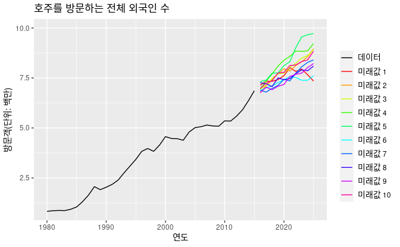

예측값을 얻으면, 확률변수(random variable)가 가질 수 있는 가능한 값들의 범위에서 가운데를 추정합니다. 종종 예측값은 확률변수(random variable)가 비교적 높은 확률로 취할 수 있는 값들의 범위를 제시하는 **예측구간(prediction interval)**을 수반합니다. 예를 들어, 95% 예측구간은 95% 확률로 실제 미래의 값을 포함할 값의 범위를 제시합니다.

그림 1.2처럼 각각의 가능한 미래를 그리는 대신, 보통은 이러한 예측구간(prediction interval)을 나타냅니다. 아래 그림은 미래 호주 외국인 방문객 수에 대한 80%와 95% 구간입니다. 파란선은 가능한 미래 값의 평균값인데, 이것을 **점예측(point forecast: 구간예측과 상반되는 개념으로 값의 범위가 아닌 특정값을 지정한다는 의미)**이라고 부릅니다.

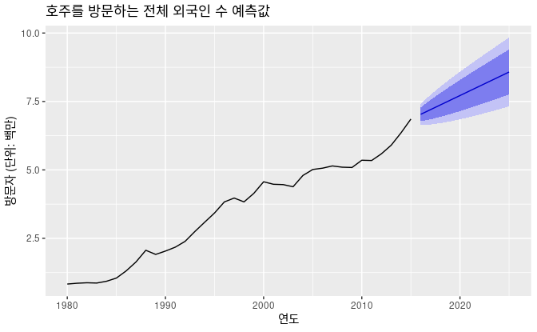

시간에 대해 $t$라는 아래첨자를 사용하겠습니다. 예를 들어, $y_t$는 시간 $t$ 에서의 관측값을 나타냅니다. 우리가 관측한 모든 정보를  
$\mathcal{I}$ 로, 우리가 예측하고 싶은 것을 $y_t$로 씁시다. 그리고 “우리가 아는 $\mathcal{I}$이 주어진 상황에서의 무작위 변수 $y_t$”를 의미하는 $y_t|\mathcal{I}$를 씁시다. 상대적인 확률 값에 따라 이 무작위 변수가 가질 수 있는 값은 $y_t|\mathcal{I}$의 “확률분포(probability distribution)”라고 합니다. 예측할 때, 이것을 **예측분포(forecast distribution)**라고 부릅니다.

“예측”을 말할 때, 보통은 예측분포(forecast distribution)의 평균을 가리키고, 나타낼 때 $y$위에 “모자 기호(hat)”을 씌웁니다. 따라서, $y_t$의 예측을, 우리가 아는 모든 것에서 $y_t$가 가질 수 있는 가능한 값의 평균을 의미하는 $\hat{y_t}$로 씁니다. 가끔, $\hat{y_t}$를 예측 분포의 중간값median (또는 중앙값) 대신에 $\hat{y_t}$로 쓸 것입니다.

예측값을 계산할 때 우리가 사용할 정보를 정확하게 정하는 것은 종종 유용합니다. 그러면 예를 들면, 모든 이전 관측값을 $(y_1,\dots,y_{t-1})$ 고려한 $y_t$의 예측을 의미하도록 $\hat{y}_{t|t-1}$을 쓸 수 있습니다. 비슷하게, $\hat{y}_{T+h|T}$은 $y_1,\dots,y_T$을 고려하는 $y_{T+h}$의 예측을 의미합니다(즉, 시간 $T$까지의 모든 관측값을 고려한 $h$단계 예측).